# miRNA target analysis (DEGs from microRNA mRNA)

Andrea Tangherloni, Department of Computing Sciences, Bocconi University (PI: Prof. Francesca Buffa)

June 29, 2023

# Resources and data files

This material has been created using the following resources:

- [multiMiR vignette](https://bioconductor.org/packages/release/bioc/vignettes/multiMiR/inst/doc/multiMiR.html)
- [miRNAtap documentation](https://bioconductor.org/packages/release/bioc/html/miRNAtap.html)
- [biomaRt vignette](https://bioconductor.org/packages/release/bioc/vignettes/biomaRt/inst/doc/accessing_other_marts.html)

# Data import

As a first step, we have to load all the packages we need for analyzing these data. Note that you can install them using the BiocManager package.

```r
# BiocManager::install("miRNAtap")
# BiocManager::install("miRNAtap.db")
# BiocManager::install("biomaRt")
# BiocManager::install("multiMiR")

# Load the packaegs
library("miRNAtap")
library("miRNAtap.db")
library("biomaRt")
library("multiMiR")
```

## Define the working directory

We can create the path to the base directory for this tutorial (i.e., the directory that contains all the data we need). Please, remember that a path is a string of characters where each directory is represented by path components. These are separated by a delimiting character that generally changes on the different platform. For example, if you used a directory called Andrea on the Desktop of your Virtual Machine as base directory, then a possible path to such directory could be `"/home/user/Desktop/Andrea"`. To build the path in a platform-independent way we can use the `file.path` R function.

```r
# Set up the working directory. Uncomment one of the following lines and modify the path accordingly.

# Example on VM
# baseDir = file.path("/home", "user", "Desktop", "Andrea")

# Example on Windows laptop
# baseDir = file.path("E:", "Personal", "Courses", "Teaching", "WT2023")

baseDir <- file.path("..", "..")
```

## Define paths to useful directories

Now we can create some other useful paths. These will be relative paths to our project directory. For example, let us create the variables `mrnaDataPath` and `analysisRes` which will contain the path to the directory where we stored the data produced during the first part of the course and the path to a result directory, respectively. For this purpose, we can use again the `file.path` R function.

```r
# Path to the directory containing the data
mrnaDataPath  <- file.path(baseDir, "course_data", "microRNA targets Module", "mRNA")
mirnaDataPath <- file.path(baseDir, "course_data", "microRNA targets Module", "miRNA")

# Path to the directory where we will store the results
analysisRes <- file.path(baseDir, "Results")

# Check if this directory exists; otherwise, we create it
if(!dir.exists(analysisRes)){dir.create(path = analysisRes, showWarnings = F, recursive = T)}

# Set the result directory for miRNA results
mirnaResDir <- file.path(analysisRes, "miRNA")

# Set dir for mir29
mirnaResDir.mir29b <- file.path(mirnaResDir, "mir-29b");

# Set dir for top 5 up-regulated and top 5 down-regulated
mirnaResDir.top5    <- file.path(mirnaResDir, "Top5")
mirnaResDir.top5.up <- file.path(mirnaResDir.top5, "Up")
mirnaResDir.top5.dw <- file.path(mirnaResDir.top5, "Down")

# Set dir for predicted and validated targets
# mir29b, top 5 UP and top 5 DOWN
mirnaPredResDir.mir29b   <- file.path(mirnaResDir.mir29b, "PredictedTargets")
mirnaValidResDir.mir29b  <- file.path(mirnaResDir.mir29b, "ValidatedTargets")
mirnaPredResDir.top5.up  <- file.path(mirnaResDir.top5.up, "PredictedTargets")
mirnaValidResDir.top5.up <- file.path(mirnaResDir.top5.up, "ValidatedTargets")
mirnaPredResDir.top5.dw  <- file.path(mirnaResDir.top5.dw, "PredictedTargets")
mirnaValidResDir.top5.dw <- file.path(mirnaResDir.top5.dw, "ValidatedTargets")

# Create the directories
if(!dir.exists(mirnaPredResDir.mir29b)) dir.create(path = mirnaPredResDir.mir29b, showWarnings = F, recursive = T)
if(!dir.exists(mirnaValidResDir.mir29b)) dir.create(path = mirnaValidResDir.mir29b, showWarnings = F, recursive = T)
if(!dir.exists(mirnaPredResDir.top5.up)) dir.create(path = mirnaPredResDir.top5.up, showWarnings = F, recursive = T)
if(!dir.exists(mirnaValidResDir.top5.up)) dir.create(path = mirnaValidResDir.top5.up, showWarnings = F, recursive = T)
if(!dir.exists(mirnaPredResDir.top5.dw)) dir.create(path = mirnaPredResDir.top5.dw, showWarnings = F, recursive = T)
if(!dir.exists(mirnaValidResDir.top5.dw)) dir.create(path = mirnaValidResDir.top5.dw, showWarnings = F, recursive = T)
```

## mRNA and miRNA data

For this tutorial, we will use the data you produced during the first part of the course (mRNA and miRNA). Firstly, let’s set up the path to the file we want to read. This should be stored in the directory pointed to by the path stored in the `mrnaDataPath` variable.

```r
# Set the file name
DESeq2.filename = "DESeq2_analysis_mRNA"

# Set the file extension
DESeq2.filext = ".csv"

# Define the path to the file we want to read
expMRNAPath = file.path(mrnaDataPath, paste0(DESeq2.filename, DESeq2.filext))

# Set the miRNA file name
mirna.filename = "WT_NREPmiR-29a" #WT_NREPscram

# Set the file extension
mirna.filext = ".csv"

# Define the path to the file we want to read
expMiRNAPath = file.path(mirnaDataPath, paste0(mirna.filename, mirna.filext))
```

Now we can read the data. The file was stored as a CSV (Comma-Separated Values) file, so we can import it in R by using the `read.csv` function. To make sure we are reading numerical values, we use the `colClasses` option.

```r
# Read the mRNA
expMRNA.data = read.csv(file = expMRNAPath, header = T, stringsAsFactors = F, colClasses = c("baseMean"="numeric", "log2FoldChange"="numeric", "lfcSE"="numeric", "stat"="numeric", "pvalue"="numeric", "padj"="numeric"));

#Read the miRNA
expMiRNA.data = read.csv(file = expMiRNAPath, header = T, colClasses = c("logFC"="numeric", "logCPM"="numeric", "PValue"="numeric", "FDR"="numeric"), stringsAsFactors = F)
```

Let’s have a look at the mRNA file

```r
DT::datatable(data = expMRNA.data)
```

|  | ensgenes | baseMean | log2FoldChange | lfcSE | stat | pvalue | padj | gene_symbol | entrezid |
| --- | --- | --- | --- | --- | --- | --- | --- | --- | --- |
| 1 | ENSMUSG00000000001 | 472.904230370118 | 0.0671984969306711 | 0.23237279597864 | 0.289184009890934 | 0.772440567612353 | 0.910990482449944 | Gnai3 | 14679 |
| 2 | ENSMUSG00000000028 | 182.300198140025 | 1.46398623322634 | 0.427168122207032 | 3.42718980447891 | 0.000609862631248302 | 0.00881513949411098 | Cdc45 | 12544 |
| 3 | ENSMUSG00000000037 | 6.64662714397539 | 1.52086505708371 | 1.37147129582118 | 1.10892955741599 | 0.267460571727953 |  | Scml2 | 107815 |
| 4 | ENSMUSG00000000056 | 149.378118491321 | -1.10752807626942 | 0.312104015206489 | -3.54858644012214 | 0.000387304852345987 | 0.00623360482180998 | Narf | 67608 |
| 5 | ENSMUSG00000000058 | 8.51755333498435 | -0.491316891329188 | 1.1356432894219 | -0.432633112796617 | 0.665281329465951 |  | Cav2 | 12390 |
| 6 | ENSMUSG00000000078 | 905.548289111793 | 0.911080833688428 | 0.248940558145917 | 3.65983285517661 | 0.000252379817362501 | 0.00448044170221036 | Klf6 | 23849 |
| 7 | ENSMUSG00000000085 | 69.5874237142093 | -0.339787952911207 | 0.401783285357737 | -0.845699573113573 | 0.397720361358666 | 0.687328523285988 | Scmh1 | 29871 |
| 8 | ENSMUSG00000000088 | 4475.47331395751 | 0.292784187102799 | 0.206650962370429 | 1.41680534048505 | 0.156539847885329 | 0.421107608339924 | Cox5a | 12858 |
| 9 | ENSMUSG00000000093 | 2.24837746982401 | -0.0319862389159013 | 1.78062266859388 | -0.0179635132586289 | 0.985667960913022 |  | Tbx2 | 21385 |
| 10 | ENSMUSG00000000126 | 2.98160146966402 | -0.333981454189501 | 1.5683325002306 | -0.212953218874438 | 0.831363451613366 |  | Wnt9a | 216795 |

[output cut: 14225 more lines]

As we can see, the file contains both Ensembl ids and gene symbols in the columns named `ensgenes` and `gene_symbol`, respectively. Let’s save this information in two variables. We will need also the log fold-change and the p-values, so let’s save also these values in 2 other variables.

```r
ensembl.colname.mrna = "ensgenes"
genesym.colname.mrna = "gene_symbol"
logfc.colname.mrna   = "log2FoldChange"
pval.colname.mrna    = "pvalue"
```

Let’s have a look at the miRNA file

```r
DT::datatable(data = expMiRNA.data)
```

|  | X | logFC | logCPM | PValue | FDR |
| --- | --- | --- | --- | --- | --- |
| 1 | mmu-mir-615-3p | -11.6665566298133 | 7.90862303718977 | 0.0432135470736478 | 0.871720779282919 |
| 2 | mmu-mir-293-3p | -11.3429182750362 | 4.79015503942113 | 0.130508997462082 | 1 |
| 3 | mmu-mir-293-5p | -11.1031068659767 | 4.5508217346338 | 0.0510153906939901 | 0.871720779282919 |
| 4 | mmu-mir-196a-5p | -10.0292756997247 | 3.50845815063356 | 0.0205108614063111 | 0.664194063217981 |
| 5 | mmu-mir-196b-5p | -9.93678917022878 | 8.57891430872927 | 0.062857964135442 | 0.871720779282919 |
| 6 | mmu-mir-295-3p | -9.78662177849163 | 3.24125837528636 | 0.149993821700764 | 1 |
| 7 | mmu-mir-10b-3p | -9.61462478000504 | 5.86134622006643 | 0.0033982667318391 | 0.331670833027496 |
| 8 | mmu-mir-543-3p | -9.40645735889632 | 2.88475791873656 | 6.68048670492692e-05 | 0.0244505813400325 |
| 9 | mmu-mir-182-3p | -9.28861556487642 | 2.72338338945895 | 0.353743077263146 | 1 |
| 10 | mmu-mir-292a-3p | -9.15638414789081 | 2.62741799453327 | 0.050653796947613 | 0.871720779282919 |

[output cut: 1454 more lines]

For the miRNA, we will need the log fold-change, the p-values and the IDs. Let’s save the information.

```r
mirna.colname       = "X";
logfc.colname.mirna = "logFC"
pval.colname.mirna  = "PValue"
```

The advantage of saving this information into variables is that in this way the code is easier to maintain.

# Predict and validate the targets for mmu-mir-29b-3p

## Format the data

We want to the extract the miR-29b-3p.

```r
# Select miR-29 family
expMiRNA.mir29 = expMiRNA.data[grep(pattern = "mmu-mir-29b-3p", expMiRNA.data[,mirna.colname]),];
print(expMiRNA.mir29)
```

```
##                  X    logFC   logCPM      PValue       FDR
## 429 mmu-mir-29b-3p 2.420988 4.974432 0.002175403 0.2653992
```

Select the mir-29b-3p id:

```r
# Select miR-29 family ids
expMiRNA.mir29b3p.id = expMiRNA.mir29[,mirna.colname];
```

## Identify the predicted targets and extract them from the analysis

We can identify the predicted targets for each miRNA using the [miRNAtap](https://bioconductor.org/packages/release/bioc/html/miRNAtap.html) R package. This package allows integration of miRNA target predictions from multiple sources available online. Targets are aggregated from 5 most commonly cited prediction algorithms:

- DIANA (Maragkakis et al., 2011)
- Miranda (Enright et al., 2003)
- PicTar (Lall et al., 2006)
- TargetScan (Friedman et al., 2009)
- miRDB (Wong and Wang, 2015)

Currently predictions are available for Homo sapiens, Mus musculus and Rattus norvegicus.

To get a list of predicted targets for a miRNA id we can use the getPredictedTargets R function. The resulting object is a data.frame object where row names are entrez IDs of target genes.

```r
# Predict the targets
predictedTargets = miRNAtap::getPredictedTargets(mirna=expMiRNA.mir29b3p.id,
                                                 sources = c("pictar", "diana", "targetscan", "miranda","mirdb"),
                                                 species = "mmu", min_src = 2,
                                                 method = "geom", promote = TRUE, synonyms = TRUE,
                                                 both_strands = FALSE)

# Check the structure of the resulting object
head(predictedTargets)
```

```
##        source_1 source_2 source_3 source_4 source_5 rank_product rank_final
## 66496        NA       NA        1        5       NA     1.118034          1
## 194388        1     25.5       34       NA        2     1.613252          2
## 12830       106      5.0        4       NA        1     1.696383          3
## 214133       23      1.0       NA       NA       21     2.615338          4
## 72290         7     10.0       NA       NA       NA     4.183300          5
## 52463         2     16.0       NA       NA       66     4.276712          6
```

We want to match the predicted targets with our experimental data, so we need to convert the Entrez ids into Ensembl or symbol ids. For this tutorial we decided to use symbols.

```r
# Set a BioMart
ensembl = biomaRt::useMart(biomart="ensembl", dataset = "mmusculus_gene_ensembl", host = "useast.ensembl.org");
if(!is.null(predictedTargets)){
    # Convert the predicted targets from entrez gene ids to mgi_symbol symbols
    attr_output = "mgi_symbol";
    attr_input = "entrezgene_id";
    predictedTargets.sym = if(!is.null(predictedTargets)){as.matrix(biomaRt::getBM(attributes=c(attr_output),
                                                                                   filters = attr_input,
                                                                                   values = row.names(predictedTargets),
                                                                                   mart = ensembl, uniqueRows = TRUE))}
    predictedTargets.sym[,1] = trimws(predictedTargets.sym[,1])

    # Check if the predicted targets are present in list of DE genes
    index = match(predictedTargets.sym, expMRNA.data[,genesym.colname.mrna])

    # Filter the NAs
    index = index[which(!is.na(index)==TRUE)]

    # Get the expression of the predicted targets
    expMRNA = expMRNA.data[index,]

    # We could store the results as rds object and csv file
    saveRDS(object = expMRNA, file = file.path(mirnaPredResDir.mir29b, "miRNAtap_predicted_ExpMRNA.rds"));
    write.csv(x = expMRNA, file = file.path(mirnaPredResDir.mir29b, "miRNAtap_predicted_ExpMRNA.csv"), row.names = F)

    # Get the number of up- and down-regulated genes (i.e. the ones with absolute value of fold change > 0)
    n.expMRNA.data.up   = length(expMRNA.data[expMRNA.data[,logfc.colname.mrna,drop=F]>0,genesym.colname.mrna])
    n.expMRNA.data.down = length(expMRNA.data[expMRNA.data[,logfc.colname.mrna,drop=F]<0,genesym.colname.mrna])
}
```

Let’s have a look at the data.

```r
if(base::exists(x = "expMRNA")) {DT::datatable(data = expMRNA)}
```

|  | ensgenes | baseMean | log2FoldChange | lfcSE | stat | pvalue | padj | gene_symbol | entrezid |
| --- | --- | --- | --- | --- | --- | --- | --- | --- | --- |
| 1299 | ENSMUSG00000015882 | 148.275391437014 | 0.0770720624064824 | 0.296544632358398 | 0.259900379222965 | 0.794940618745403 | 0.922338694532539 | Lcorl | 209707 |
| 1166 | ENSMUSG00000014592 | 470.580098520626 | 0.0676431813912181 | 0.228679824801935 | 0.295798640959278 | 0.767383860937795 | 0.908631087254049 | Camta1 | 100072 |
| 9303 | ENSMUSG00000041132 | 48.3936009828135 | -1.6160946539275 | 0.571235981564916 | -2.82911914879761 | 0.00466763179556084 | 0.0405953504455532 | N4bp2l1 | 100637 |
| 7319 | ENSMUSG00000034021 | 169.393684038075 | 0.354494637977835 | 0.287674759870898 | 1.23227577607755 | 0.217846085459775 | 0.50853123957304 | Pds5b | 100710 |
| 10996 | ENSMUSG00000051674 | 88.7812346806444 | -0.156901669950655 | 0.36375065779814 | -0.431344017081409 | 0.666218249359866 | 0.860011305702224 | Dcun1d4 | 100737 |
| 4033 | ENSMUSG00000025821 | 42.5648918617446 | -0.480159030287072 | 0.49276912454827 | -0.974409731387375 | 0.329853139550338 | 0.628510778915273 | Zfp282 | 101095 |
| 9692 | ENSMUSG00000042742 | 56.3989978973896 | -0.345212636155779 | 0.442099093292211 | -0.780849002844722 | 0.434891309046629 | 0.717157727652045 | Bmt2 | 101148 |
| 5863 | ENSMUSG00000030022 | 57.8018689448515 | -0.555319062051082 | 0.44625551987121 | -1.2443970714611 | 0.213353460211297 | 0.501499560921835 | Adamts9 | 101401 |
| 9065 | ENSMUSG00000040268 | 199.423551132009 | -0.87756289438679 | 0.352210812032642 | -2.49158420016209 | 0.0127174819665529 | 0.0839791894268467 | Plekha1 | 101476 |
| 3921 | ENSMUSG00000025485 | 153.650176861252 | 0.423956964699012 | 0.310471913397187 | 1.36552437243057 | 0.172088298167107 | 0.444075815726315 | Ric8a | 101489 |

[output cut: 708 more lines]

Now we want to understand the proportion of up-regulated and down-regulated genes. Instead of considering just one fold change value to discriminate between up- and down-regulated, we could create a set of values (i.e. thresholds).

```r
# Set the thresholds we want to consider
thresholds = seq(from = 0, to = 3, by = 0.5)
```

Sometimes it helps to have a pre-allocated object (in this case we will use a `data.frame`). This could improve the speed.

```r
# Create pre-allocated data.frame where to store the results
df.size = length(thresholds)
resTable = data.frame(ids=character(df.size),
                      threshold=numeric(df.size),
                      n_targets=numeric(df.size),
                      ratio=numeric(df.size),
                      proportion=numeric(df.size),
                      stringsAsFactors = F)
```

Now we compute an “activation score” for each threshold.

```r
for(t.i in 1:length(thresholds)){

  threshold.i = thresholds[t.i];

  if(!is.null(predictedTargets)){

    #Check if proportion of predicted targets with FC<0 is significantly greater than the proportion of PT with FC>0

    #Select the genes expressed over the consider threshold
    expMRNA.up   = expMRNA[which(expMRNA[,logfc.colname.mrna,drop=F]>threshold.i),];
    expMRNA.down = expMRNA[which(expMRNA[,logfc.colname.mrna,drop=F]<(-threshold.i)),];

    #Compute the ratio and proportion
    n.expMRNA.up = length(expMRNA.up[,1]);
    ratio.up = 1/(length(expMRNA.up[,1])/length(expMRNA.down[,1]));
    proportion.up = 1/((length(expMRNA.up[,1])/(n.expMRNA.data.up))/(length(expMRNA.down[,1])/n.expMRNA.data.down));
  } else {
    n.expMRNA.up = NA;
    ratio.up = NA;
    proportion.up = NA;
  }

  # Store the results in the table
  resTable[t.i, ] = c(expMiRNA.mir29b3p.id, threshold.i, n.expMRNA.up, ratio.up, proportion.up)

}


print(resTable)
```

```
##              ids threshold n_targets            ratio       proportion
## 1 mmu-mir-29b-3p         0       330 1.17575757575758 1.09982489751354
## 2 mmu-mir-29b-3p       0.5       131  1.3206106870229 1.23532311716078
## 3 mmu-mir-29b-3p         1        49 1.46938775510204 1.37449187696833
## 4 mmu-mir-29b-3p       1.5        28              1.5 1.40312712440517
## 5 mmu-mir-29b-3p         2        12             1.75 1.63698164513936
## 6 mmu-mir-29b-3p       2.5         5              2.2 2.05791978246091
## 7 mmu-mir-29b-3p         3         2                4 3.74167233174711
```

```r
# Save the results
resFilePath = file.path(mirnaPredResDir.mir29b, "regulated_multpleT.csv")
write.csv(x=resTable, file = resFilePath, row.names = T)
```

## Plot the ratio vs FC threshold

We want to plot a miRNA activation score vs the set of pre-defined thresholds.

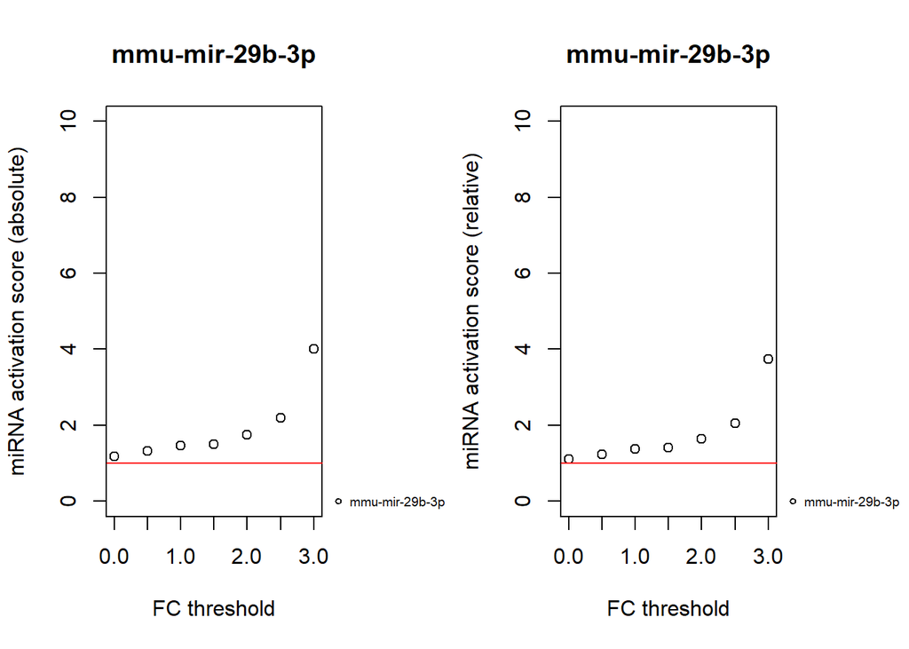

```r
#Create the plots

mar.default = par()$mar
{
par(mfrow=c(1,2), xpd = T, mar = mar.default + c(0,0,0,3))
plot(x = resTable$threshold, y = resTable$ratio, xlab="FC threshold",
     ylab="miRNA activation score (absolute)", main=expMiRNA.mir29b3p.id,
     col = "black", ylim=c(0,10))
abline(h = 1, xpd = F, col="red")

legend(x = 'bottomright',inset = c(-0.6,0), xpd = T,
       legend = expMiRNA.mir29b3p.id,
       col = "black",
       pch = par("pch"), bty = 'n', xjust = 1,cex=0.6)

plot(x = resTable$threshold, y = resTable$proportion, xlab="FC threshold",
     ylab="miRNA activation score (relative)", main=expMiRNA.mir29b3p.id,
     col="black", ylim=c(0,10))
abline(h = 1, xpd = F, col="red")

legend(x = 'bottomright',inset = c(-0.6,0), xpd = T,
       legend = expMiRNA.mir29b3p.id,
       col = "black",
       pch = par("pch"), bty = 'n', xjust = 1,cex=0.6)

}
```

Let us consider the left plot. Each dot in it represents the ratio between the number of down- and up-regulated predicted mRNA targets of `mmu-mir-29b-3p`. Given that the red horizontal line stands at `1`, dots up the line correspond to an higher number of down-regulated targets than up-regulated ones.

## miRNA validated targets

Validated targets for different miRNAs and are available from different databases. For this course, we decided to use the [multiMiR](http://multimir.ucdenver.edu/) database, which contains human and mouse data from 14 external databases, including:

- three validated miRNA-target databases ( [miRecords](http://c1.accurascience.com/miRecords/), [miRTarBase](http://mirtarbase.mbc.nctu.edu.tw/php/index.php) and [TarBase](http://carolina.imis.athena-innovation.gr/diana_tools/web/index.php?r=tarbasev8%2Findex))
- eight predicted miRNA-target databases ( [DIANA-microT](http://diana.imis.athena-innovation.gr/DianaTools/index.php?r=mrmicrot/index), [TargetScan](http://www.targetscan.org/vert_72/), [ElMMo](http://www.clipz.unibas.ch/ElMMo3/), MicroCosm, [miRanda](http://cbio.mskcc.org/miRNA2003/miranda.html), [miRDB](http://www.mirdb.org/), [PicTar](https://pictar.mdc-berlin.de/) and [PITA](https://genie.weizmann.ac.il/pubs/mir07/mir07_prediction.html))
- three disease-/drug-related miRNA databases ( [miR2Disease](http://www.mir2disease.org/), [Pharmaco-miR](http://www.pharmaco-mir.org/) and [PhenomiR](http://mips.helmholtz-muenchen.de/phenomir))

### Get the targets

We want to retrieve the validated targets for of mmu-miR-29b-3p using the [multiMiR](https://bioconductor.org/packages/release/bioc/html/multiMiR.html) R package which take advantage of different existing database.

```r
multimirResults = get_multimir(org = 'mmu',
                               mirna = 'mmu-miR-29b-3p',
                               table   = 'validated',
                               summary = FALSE)
```

```
## Searching mirecords ...
## Searching mirtarbase ...
## Searching tarbase ...
```

We can extract the validated targets ids:

```r
#Extract the validated target symbol from the data structure
validatedTargets = multimirResults@data$target_symbol;

#Validated targets can be present in multiple databases, so we eliminate the duplicates
validatedTargets = unique(validatedTargets);
```

We want now to investigate the retrieved validated targets in our experiments.

```r
########################################################
# Create table with all validated targets for mir-29b-3p
# and attach FC and p-value
########################################################
if(length(validatedTargets)>0)
{

  index = match(validatedTargets, expMRNA.data[,genesym.colname.mrna])
  index = index[which(!is.na(index)==TRUE)]
  validatedTargets.expData = expMRNA.data[index,];

  #We could store the results as rds object
  saveRDS(object = validatedTargets.expData, file = file.path(mirnaValidResDir.mir29b, "multiMiR_validated_ExpMRNA_DESEq2.rds"));
  #as csv file
  write.csv(x = validatedTargets.expData, file = file.path(mirnaValidResDir.mir29b, "multiMiR_validated_ExpMRNA_DESEq2.csv"), row.names = F)

  #See the results
  print(validatedTargets.expData[1:40, c("log2FoldChange", "pvalue", "stat", "gene_symbol")]);
}
```

```
##       log2FoldChange       pvalue        stat gene_symbol
## 5770      0.44271266 3.669178e-01  0.90226175         Eln
## 4609      1.57821926 7.317522e-03  2.68203765        Fbn1
## 4122      0.20618785 8.932191e-01  0.13423204      Col3a1
## 197      -2.23959175 1.637005e-02 -2.40055892      Col1a1
## 2361      0.08230195 8.061385e-01  0.24541058         Yy1
## 4240      0.11570127 6.856253e-01  0.40479890       Hdac4
## 2353     -0.31446524 5.942337e-01 -0.53271091       Tgfb3
## 11044    -0.31823034 5.657127e-01 -0.57437697      Acvr2a
## 4688      2.02074293 3.238063e-01  0.98666621       Dusp2
## 542       1.58890828 2.208823e-01  1.22418550      Col5a3
## 6426      0.69500806 2.401333e-01  1.17465370      Col4a2
## 5667      0.09892276 6.473017e-01  0.45751389       Arpc3
## 3261     -0.28226874 5.146295e-01 -0.65164609       Vegfa
## 6715     -0.37531217 1.944653e-01 -1.29748224       Bace1
```

[output cut: 26 more lines]

### Get the targets

```r
#Retrieve the validated targets for mmu-mir29b-3p
multimirResults <- multiMiR::get_multimir(org = 'mmu',
                                          mirna   = expMiRNA.mir29b3p.id,
                                          table   = 'validated',
                                          summary = FALSE)
```

```
## Searching mirecords ...
## Searching mirtarbase ...
## Searching tarbase ...
```

We can extract the validated targets ids:

```r
#Extract the validated target symbol from the data structure
validatedTargets = multimirResults@data$target_symbol;

#Validated targets can be present in multiple databases, so we eliminate the duplicates
validatedTargets = unique(validatedTargets);
```

We want now to investigate the retrieved validated targets in our experiments.

```r
########################################################
# Create table with all validated targets for mir-29b-3p
# and attach FC and p-value
########################################################
if(length(validatedTargets)>0) {

  index = match(validatedTargets, expMRNA.data[,genesym.colname.mrna])
  index = index[which(!is.na(index)==TRUE)]
  validatedTargets.expData = expMRNA.data[index,];

  #We could store the results
  #as rds object
  saveRDS(object = validatedTargets.expData, file = file.path(mirnaValidResDir.mir29b, "multiMiR_validated_ExpMRNA.rds"));
  #as csv file
  write.csv(x = validatedTargets.expData, file = file.path(mirnaValidResDir.mir29b, "multiMiR_validated_ExpMRNA.csv"), row.names = F)

  #See the results
  print(validatedTargets.expData);
}
```

```
##                 ensgenes     baseMean log2FoldChange     lfcSE          stat
## 5770  ENSMUSG00000029675    39.488112   4.427127e-01 0.4906699  9.022618e-01
## 4609  ENSMUSG00000027204    39.179760   1.578219e+00 0.5884404  2.682038e+00
## 4122  ENSMUSG00000026043    50.844488   2.061879e-01 1.5360554  1.342320e-01
## 197   ENSMUSG00000001506    11.897278  -2.239592e+00 0.9329460 -2.400559e+00
## 2361  ENSMUSG00000021264   107.663400   8.230195e-02 0.3353643  2.454106e-01
## 4240  ENSMUSG00000026313   311.264936   1.157013e-01 0.2858241  4.047989e-01
## 2353  ENSMUSG00000021253    27.386907  -3.144652e-01 0.5903112 -5.327109e-01
## 11044 ENSMUSG00000052155    30.824112  -3.182303e-01 0.5540444 -5.743770e-01
## 4688  ENSMUSG00000027368     2.109201   2.020743e+00 2.0480512  9.866662e-01
## 542   ENSMUSG00000004098     4.949947   1.588908e+00 1.2979310  1.224186e+00
## 6426  ENSMUSG00000031503    31.737947   6.950081e-01 0.5916706  1.174654e+00
## 5667  ENSMUSG00000029465  1414.199995   9.892276e-02 0.2162180  4.575139e-01
## 3261  ENSMUSG00000023951    52.097518  -2.822687e-01 0.4331626 -6.516461e-01
## 6715  ENSMUSG00000032086   186.351840  -3.753122e-01 0.2892619 -1.297482e+00
```

[output cut: 3223 more lines]

# Predict and validate the targets for the 5 most up-regulated and down-regulated miRNAs

Now we could repeat the analysis considering the 5 most up-regulated and down-regulated miRNAs instead of mir-29b-3p.

## Format the data

For time reasons, we are only going to consider the 5 most up-regulated and down-regulated miRNAs. Let’s have a look at the 5 most up-regulated:

```r
# Sort the data according to logFC
expMiRNA.up = expMiRNA.up[base::order(expMiRNA.up[logfc.colname.mirna], decreasing = T),]
# Select the 5 most up-regulated and down-regulated miRNAs
endSel = 5; #choose first 5 miRNA from the list
expMiRNATop.up = expMiRNA.up[1:endSel,];

#Look at the data
print(expMiRNATop.up)
```

```
##                  X    logFC    logCPM      PValue       FDR
## 49 mmu-mir-3090-5p 5.600701 -1.236614 0.004890076 0.3853381
## 51 mmu-mir-7047-5p 5.412297 -1.320384 0.010174850 0.4730359
## 68 mmu-mir-6910-3p 4.940358 -1.506260 0.022763269 0.6801107
## 92    mmu-mir-6394 4.630129 -1.610356 0.056064640 0.8717208
## 93 mmu-mir-7000-5p 4.630129 -1.610356 0.056064640 0.8717208
```

Now, let’s have a look at the most down-regulated:

```r
#Sort the data according to logFC
expMiRNA.down = expMiRNA.down[base::order(expMiRNA.down[logfc.colname.mirna], decreasing = F),]
#Select the 5 most up-regulated and down-regulated miRNAs
endSel = 5; #choose first 5 miRNA from the list
expMiRNATop.down = expMiRNA.down[1:endSel,];

#Look at the data
print(expMiRNATop.down)
```

```
##                 X      logFC   logCPM     PValue       FDR
## 1  mmu-mir-615-3p -11.666557 7.908623 0.04321355 0.8717208
## 2  mmu-mir-293-3p -11.342918 4.790155 0.13050900 1.0000000
## 3  mmu-mir-293-5p -11.103107 4.550822 0.05101539 0.8717208
## 4 mmu-mir-196a-5p -10.029276 3.508458 0.02051086 0.6641941
## 5 mmu-mir-196b-5p  -9.936789 8.578914 0.06285796 0.8717208
```

```r
# Extract the ids
expMiRNA.up.ids = expMiRNATop.up[,mirna.colname]
expMiRNA.down.ids = expMiRNATop.down[,mirna.colname]

# Select the 5 most up-regulated and down-regulated miRNAs
endSel = 5; #choose first 5 miRNA from the list
expMiRNATop.up.ids = expMiRNA.up.ids[1:endSel]
expMiRNATop.down.ids = expMiRNA.down.ids[1:endSel]
```

## Identify the predicted targets and extract them from the analysis

We can identify the predicted targets for each miRNA using the [miRNAtap](https://bioconductor.org/packages/release/bioc/html/miRNAtap.html) R package. This package allows integration of miRNA target predictions from multiple sources available online. Targets are aggregated from 5 most commonly cited prediction algorithms:

- DIANA (Maragkakis et al., 2011)
- Miranda (Enright et al., 2003)
- PicTar (Lall et al., 2006)
- TargetScan (Friedman et al., 2009)
- miRDB (Wong and Wang, 2015)

Currently predictions are available for Homo sapiens, Mus musculus and Rattus norvegicus.

To get a list of predicted targets for a miRNA id we can use the getPredictedTargets R function. The resulting object is a data.frame object where row names are entrez IDs of target genes.

Firstly, let’s predict the targets.

```r
predictedTargets.up   = list();
predictedTargets.down = list();

for(miRNA.i in 1:endSel){
  miRNA.i.up.id   = expMiRNATop.up.ids[miRNA.i]
  miRNA.i.down.id = expMiRNATop.down.ids[miRNA.i]

  predictedTargets.up[[miRNA.i]]   = miRNAtap::getPredictedTargets(mirna=miRNA.i.up.id,
                                                                   sources = c("pictar", "diana", "targetscan", "miranda","mirdb"),
                                                                   species = "mmu",
                                                                   min_src = 2,
                                                                   method = "geom",
                                                                   promote = TRUE,
                                                                   synonyms = TRUE,
                                                                   both_strands = FALSE)

  predictedTargets.down[[miRNA.i]] = miRNAtap::getPredictedTargets(mirna=miRNA.i.down.id,
                                                                   sources = c("pictar", "diana", "targetscan", "miranda","mirdb"),
                                                                   species = "mmu",
                                                                   min_src = 2,
                                                                   method = "geom",
                                                                   promote = TRUE,
                                                                   synonyms = TRUE,
                                                                   both_strands = FALSE)
}
```

We want to match the predicted targets with our experimental data, so we need to convert the Entrez ids into Ensembl or symbol ids. For this tutorial we decided to use symbols. Let’s do it for the up-regulated miRNA first.

```r
# Set a BioMart
ensembl = biomaRt::useMart(biomart="ensembl", host = "useast.ensembl.org", dataset = "mmusculus_gene_ensembl");
predictedTargets.sym.up = list();

for(miRNA.i in 1:endSel){
  miRNA.i.up.id = expMiRNATop.up.ids[miRNA.i];
  tmp.predictedTargets.up = predictedTargets.up[[miRNA.i]];

  if(!is.null(tmp.predictedTargets.up)){
  #Convert the predicted targets from entrez gene ids to mgi_symbol symbols
    attr_output = "mgi_symbol";
    attr_input = "entrezgene_id";

    predictedTargets.sym = if(!is.null(tmp.predictedTargets.up)){as.matrix(biomaRt::getBM(attributes=c(attr_output),
                                                                                          filters = attr_input,
                                                                                          values = row.names(tmp.predictedTargets.up),
                                                                                          mart = ensembl,
                                                                                          uniqueRows = TRUE))}

    predictedTargets.sym[,1] = trimws(predictedTargets.sym[,1])

    #Store the converted ids
    predictedTargets.sym.up[[miRNA.i]] = predictedTargets.sym;
  }

}
```

Now let’s consider the down-regulated.

```r
# Create a list where to store the converted ids
predictedTargets.sym.dw = list();

for(miRNA.i in 1:endSel){
  miRNA.i.down.id = expMiRNATop.down.ids[miRNA.i];
  tmp.predictedTargets.dw = predictedTargets.down[[miRNA.i]];

  if(!is.null(tmp.predictedTargets.dw)){
    # Convert the predicted targets from entrez gene ids to mgi_symbol symbols
    attr_output = "mgi_symbol";
    attr_input  = "entrezgene_id";

    predictedTargets.sym = if(!is.null(tmp.predictedTargets.dw)){as.matrix(biomaRt::getBM(attributes=c(attr_output),
                                                                                          filters = attr_input,
                                                                                          values = row.names(tmp.predictedTargets.dw),
                                                                                          mart = ensembl,
                                                                                          uniqueRows = TRUE))}

    predictedTargets.sym[,1] = trimws(predictedTargets.sym[,1])

    # Store the converted ids
    predictedTargets.sym.dw[[miRNA.i]] = predictedTargets.sym;

  }

}
```

Now we want to understand the proportion of up-regulated and down-regulated genes. Instead of considering just one fold change value to discriminate between up- and down-regulated, we could create a set of values (i.e. thresholds).

```r
#Set the thresholds we want to consider
thresholds = seq(from = 0, to = 3, by = 0.5)
```

Now we can compute an “activation score” for each miRNA, considering the different thresholds. Let’s do it for the top5 up-regulated miRNA first.

```r
resTableUp = data.frame(ids=character(df.size),
                        threshold=numeric(df.size),
                        n_targets=numeric(df.size),
                        ratio=numeric(df.size),
                        proportion=numeric(df.size),
                        stringsAsFactors = F)

for(miRNA.i in 1:endSel){
  miRNA.i.up.id   = expMiRNATop.up.ids[miRNA.i];
  miRNA.i.down.id = expMiRNATop.down.ids[miRNA.i];

  tmp.predictedTargets.up = predictedTargets.up[[miRNA.i]];
  tmp.predictedTargets.dw = predictedTargets.down[[miRNA.i]];

  if(!is.null(tmp.predictedTargets.up)){
    predictedTargets.sym = predictedTargets.sym.up[[miRNA.i]];

    # Check if the predicted targets are present in list of DE genes
    index = match(predictedTargets.sym, expMRNA.data[, genesym.colname.mrna])

    # Filter the NAs
    index = index[which(!is.na(index)==TRUE)]

    # Get the expression of the predicted targets
    expMRNA = expMRNA.data[index,]

    # We can store the results as a rds object and a csv file
    saveRDS(object = expMRNA, file = file.path(mirnaPredResDir.top5.up, paste0(miRNA.i.up.id,"_miRNAtap_ExpMRNA.rds")));
    write.csv(x = expMRNA, file = file.path(mirnaPredResDir.top5.up, paste0(miRNA.i.up.id, "_miRNAtap_ExpMRNA.csv")), row.names = F)

    # Get the number of up- and down-regulated genes (i.e. the ones with absolute value of fold change > 0)
    n.expMRNA.data.up   = length(expMRNA.data[expMRNA.data[, logfc.colname.mrna, drop=F]>0, genesym.colname.mrna])
    n.expMRNA.data.down = length(expMRNA.data[expMRNA.data[, logfc.colname.mrna, drop=F]<0, genesym.colname.mrna])
  }

  for(t.i in 1:length(thresholds)){

    threshold.i = thresholds[t.i];
    ###############################
    # up-regulated
    ###############################
    if(!is.null(tmp.predictedTargets.up)){


      expMRNA.up   = expMRNA[which(expMRNA[, logfc.colname.mrna]>threshold.i),];
      expMRNA.down = expMRNA[which(expMRNA[, logfc.colname.mrna]<(-threshold.i)),];

      #Compute the ratio and proportion
      n.expMRNA.up = length(expMRNA.up[,1]);
      ratio.up = 1/(length(expMRNA.up[,1])/length(expMRNA.down[,1]));
      proportion.up = 1/((length(expMRNA.up[,1])/(n.expMRNA.data.up))/(length(expMRNA.down[,1])/n.expMRNA.data.down));
    }
    else {
      n.expMRNA.up  = NA;
      ratio.up      = NA;
      proportion.up = NA;
    }

    # resTableUp[miRNA.i.up.id,] = cbind(threshold.i, n.expMRNA.up, ratio.up, proportion.up);
    resTableUp[t.i + (miRNA.i-1)*length(thresholds), ] = c(miRNA.i.up.id, threshold.i, n.expMRNA.up, ratio.up, proportion.up)
  }

}
```

Now let’s consider the down-regulated.

```r
df.size = endSel*length(thresholds);

resTableDown = data.frame(ids=character(df.size),
                          threshold=numeric(df.size),
                          n_targets=numeric(df.size),
                          ratio=numeric(df.size),
                          proportion=numeric(df.size),
                          stringsAsFactors = F)

for(miRNA.i in 1:endSel){
  miRNA.i.down.id = expMiRNATop.down.ids[miRNA.i];
  tmp.predictedTargets.dw = predictedTargets.down[[miRNA.i]];

  if(!is.null(tmp.predictedTargets.dw)){
    predictedTargets.sym = predictedTargets.sym.dw[[miRNA.i]];

    # Check if the predicted targets are present in list of DE genes
    index = match(predictedTargets.sym, expMRNA.data[, genesym.colname.mrna])

    # Filter the NAs
    index = index[which(!is.na(index)==TRUE)]

    # Get the expression of the predicted targets
    expMRNA = expMRNA.data[index,]

    # We can store the results a rds object and as csv file
    saveRDS(object = expMRNA, file = file.path(mirnaPredResDir.top5.dw, paste0(miRNA.i.down.id,"_miRNAtap_ExpMRNA.rds")));
    write.csv(x = expMRNA, file = file.path(mirnaPredResDir.top5.dw, paste0(miRNA.i.down.id, "_miRNAtap_ExpMRNA.csv")), row.names = F)

    # Get the number of up- and down-regulated genes (i.e. the ones with absolute value of fold change > 0)
    n.expMRNA.data.up   = length(expMRNA.data[expMRNA.data[, logfc.colname.mrna, drop=F]>0, genesym.colname.mrna])
    n.expMRNA.data.down = length(expMRNA.data[expMRNA.data[, logfc.colname.mrna, drop=F]<0, genesym.colname.mrna])
  }

  for(t.i in 1:length(thresholds)){

    threshold.i = thresholds[t.i];
    ###############################
    # up-regulated
    ###############################
    if(!is.null(tmp.predictedTargets.dw)){

      expMRNA.up   = expMRNA[which(expMRNA[, logfc.colname.mrna]>threshold.i),];
      expMRNA.down = expMRNA[which(expMRNA[, logfc.colname.mrna]<(-threshold.i)),];

      #Compute the ratio and proportion
      n.expMRNA.down = length(expMRNA.up[,1]);
      ratio.down = length(expMRNA.up[,1])/length(expMRNA.down[,1]);
      proportion.down = (length(expMRNA.up[,1])/(n.expMRNA.data.up))/(length(expMRNA.down[,1])/n.expMRNA.data.down);
    }
    else {
      n.expMRNA.down  = NA;
      ratio.down      = NA;
      proportion.down = NA;
    }

    resTableDown[t.i + (miRNA.i-1)*length(thresholds), ] = c(miRNA.i.down.id, threshold.i, n.expMRNA.down, ratio.down, proportion.down)
  }

}
```

## Plot the ratio vs FC threshold

We want to plot a miRNA activation score vs a set of pre-defined thresholds.

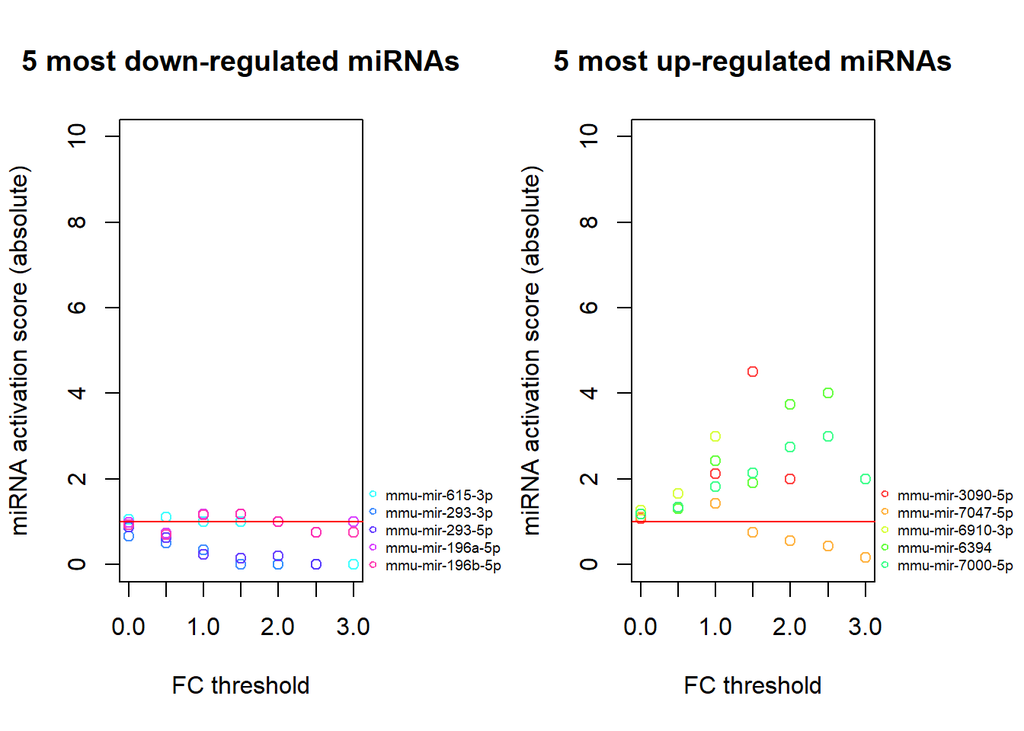

```r
#1) set up the colours: each miRNA will have the same colour
random_colors = grDevices::rainbow(endSel*2, s = 0.8, v = 1, alpha = 0.9)
p.colors = data.frame(ids=c(unique(resTableUp$ids), unique(resTableDown$ids)), colors=random_colors, stringsAsFactors = F)

col.dw = p.colors[match(resTableDown$ids, p.colors$ids),]
col.up = p.colors[match(resTableUp$ids, p.colors$ids),]

#2) plot it and store it as pdf
#pdf(file = file.path(resDirPath, "scatterplot.pdf"), width = 9, height = 7)
mar.default = par()$mar
{
par(mfrow=c(1,2), xpd = T, mar = mar.default + c(0,0,0,3))
plot(x = resTableDown$threshold, y = resTableDown$ratio, xlab="FC threshold",
     ylab="miRNA activation score (absolute)", main=paste(endSel, "most down-regulated miRNAs"),
     col=col.dw$colors, ylim=c(0,10))
abline(h = 1, xpd = F, col="red")

legend(x = 'bottomright',inset = c(-0.6,0), xpd = T,
       legend = as.character(unique(resTableDown$ids)),
       col = p.colors[p.colors$ids==unique(resTableDown$ids),2],
       pch = par("pch"), bty = 'n', xjust = 1,cex=0.6)


plot(x = resTableUp$threshold, y = resTableUp$ratio, xlab="FC threshold",
     ylab="miRNA activation score (absolute)", main=paste(endSel, "most up-regulated miRNAs"),
     col=col.up$colors, ylim=c(0,10))
abline(h = 1, xpd = F, col="red")

legend(x = 'bottomright',inset = c(-0.6, 0), xpd = T,
       legend = as.character(unique(resTableUp$ids)),
       col = p.colors[p.colors$ids==unique(resTableUp$ids),2],
       pch = par("pch"), bty = 'n', xjust = 1,cex=0.6)
}
```

```r
#dev.off()
```

## Plot the proportion vs FC threshold

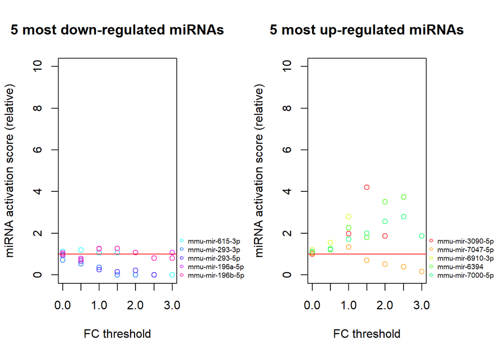

```r
{
par(mfrow=c(1,2), xpd = T, mar = mar.default + c(0,0,0,3))
plot(x = resTableDown$threshold, y = resTableDown$proportion, xlab="FC threshold",
     ylab="miRNA activation score (relative)", main=paste(endSel, "most down-regulated miRNAs"),
     col=col.dw$colors, ylim=c(0,10))
abline(h = 1, xpd = F, col="red")

legend(x = 'bottomright',inset = c(-0.6,0), xpd = T,
       legend = as.character(unique(resTableDown$ids)),
       col = p.colors[p.colors$ids==unique(resTableDown$ids),2],
       pch = par("pch"), bty = 'n', xjust = 1,cex=0.6)

plot(x = resTableUp$threshold, y = resTableUp$proportion, xlab="FC threshold",
     ylab="miRNA activation score (relative)", main=paste(endSel, "most up-regulated miRNAs"),
     col=col.up$colors, ylim=c(0,10))
abline(h = 1, xpd = F, col="red")

legend(x = 'bottomright',inset = c(-0.6, 0), xpd = T,
       legend = as.character(unique(resTableUp$ids)),
       col = p.colors[p.colors$ids==unique(resTableUp$ids),2],
       pch = par("pch"), bty = 'n', xjust = 1,cex=0.6)

}
```

## miRNA validated targets

Validated targets for different miRNAs and are available from different databases. For this course, we decided to use the [multiMiR](http://multimir.ucdenver.edu/) database, which contains human and mouse data from 14 external databases, including:

- three validated miRNA-target databases ( [miRecords](http://c1.accurascience.com/miRecords/), [miRTarBase](http://mirtarbase.mbc.nctu.edu.tw/php/index.php) and [TarBase](http://carolina.imis.athena-innovation.gr/diana_tools/web/index.php?r=tarbasev8%2Findex))
- eight predicted miRNA-target databases ( [DIANA-microT](http://diana.imis.athena-innovation.gr/DianaTools/index.php?r=mrmicrot/index), [TargetScan](http://www.targetscan.org/vert_72/), [ElMMo](http://www.clipz.unibas.ch/ElMMo3/), MicroCosm, [miRanda](http://cbio.mskcc.org/miRNA2003/miranda.html), [miRDB](http://www.mirdb.org/), [PicTar](https://pictar.mdc-berlin.de/) and [PITA](https://genie.weizmann.ac.il/pubs/mir07/mir07_prediction.html))
- three disease-/drug-related miRNA databases ( [miR2Disease](http://www.mir2disease.org/), [Pharmaco-miR](http://www.pharmaco-mir.org/) and [PhenomiR](http://mips.helmholtz-muenchen.de/phenomir))

### Get the targets

We want to retrieve validated targets for the top 5 miRNAs (up- and down-regulated) using the [multiMiR](https://bioconductor.org/packages/release/bioc/html/multiMiR.html) R package which take advantage of different existing database.

```r
validatedTargetsUp   = list();
validatedTargetsDown = list();
# miRNA.i = 3 #debug

for(miRNA.i in 1:endSel){

  miRNA.i.up.id      <- expMiRNATop.up.ids[miRNA.i];
  multimirResults.up <- multiMiR::get_multimir(org     = 'mmu',
                                               mirna   = miRNA.i.up.id,
                                               table   = 'validated',
                                               summary = FALSE)

  validatedTargetsUp[[miRNA.i.up.id]] <- multimirResults.up@data$target_symbol;

  miRNA.i.down.id      <- expMiRNATop.down.ids[miRNA.i];
  multimirResults.down <- multiMiR::get_multimir(org     = 'mmu',
                                                 mirna   = miRNA.i.down.id,
                                                 table   = 'validated',
                                                 summary = FALSE);

  validatedTargetsDown[[miRNA.i.down.id]] <- multimirResults.down@data$target_symbol;
}
```

```
## Searching mirecords ...
## Searching mirtarbase ...
## Searching tarbase ...
## Searching mirecords ...
## Searching mirtarbase ...
## Searching tarbase ...
## Searching mirecords ...
## Searching mirtarbase ...
## Searching tarbase ...
## Searching mirecords ...
## Searching mirtarbase ...
## Searching tarbase ...
## Searching mirecords ...
## Searching mirtarbase ...
## Searching tarbase ...
## Searching mirecords ...
## Searching mirtarbase ...
## Searching tarbase ...
## Searching mirecords ...
## Searching mirtarbase ...
## Searching tarbase ...
## Searching mirecords ...
## Searching mirtarbase ...
## Searching tarbase ...
## Searching mirecords ...
## Searching mirtarbase ...
## Searching tarbase ...
## Searching mirecords ...
## Searching mirtarbase ...
## Searching tarbase ...
```

We want now to investigate the retrieved validated targets in our experiments. Let’s look first at the top up-regulated.

```r
#####################################################
# Create table with all validated targets for top 5
# miRNAs (up) and attach FC and p-value
#####################################################
validatedTargetsUp.fc = list()

#Top up-regulated
if(length(validatedTargetsUp)>0) {
  for(miRNA.i in 1:length(validatedTargetsUp)){

    miRNA.i.up.id = names(validatedTargetsUp)[miRNA.i]
    index = match(validatedTargetsUp[[miRNA.i.up.id]], expMRNA.data[, genesym.colname.mrna])
    index = index[which(!is.na(index)==TRUE)]
    expMRNA.up = expMRNA.data[index,]
    validatedTargetsUp.fc[[miRNA.i.up.id]] = expMRNA.up[, c(2,3,4)];

    # We can store the results as an rds object and a csv file
    saveRDS(object = expMRNA.up, file = file.path(mirnaValidResDir.top5.up, paste0(miRNA.i.up.id,"_multiMiR_ExpMRNA.rds")))
    write.csv(x = expMRNA.up, file = file.path(mirnaValidResDir.top5.up, paste0(miRNA.i.up.id,"_multiMiR_ExpMRNA.csv")), row.names = F)

    print(validatedTargetsUp.fc[[miRNA.i.up.id]])
  }
}
```

```
##      baseMean log2FoldChange    lfcSE
## 1782 3.423168      -2.244198 1.751928
```

Finally, let’s consider the top down-regulated.

```r
#####################################################
# Create table with all validated targets for top 5
# miRNAs (down) and attach FC and p-value
#####################################################
validatedTargetsDown.fc = list()

# Top down-regulated
if(length(validatedTargetsDown)>0){
  miRNA.i = 1#debug
  for(miRNA.i in 1:length(validatedTargetsDown)){
    miRNA.i.down.id = names(validatedTargetsDown)[miRNA.i]
    index = match(validatedTargetsDown[[miRNA.i.down.id]], expMRNA.data[,genesym.colname.mrna])
    index = index[which(!is.na(index)==TRUE)]
    expMRNA.down = expMRNA.data[index,]
    validatedTargetsDown.fc[[miRNA.i.down.id]] = expMRNA.down[, c(2,3,4)]

  # We could store the results as an rds object and a csv file
  saveRDS(object = expMRNA.down, file = file.path(mirnaValidResDir.top5.dw, paste0(miRNA.i.down.id,"_multiMiR_ExpMRNA.rds")));
  write.csv(x = expMRNA.down, file = file.path(mirnaValidResDir.top5.dw, paste0(miRNA.i.down.id,"_multiMiR_ExpMRNA.csv")), row.names = F)

    print(validatedTargetsDown.fc[[miRNA.i.down.id]])
  }
}
```

```
##        baseMean log2FoldChange     lfcSE
## 11455 111.55292      0.1247671 0.3257045
## 5514   15.67046     -0.4489896 0.7523841
## 11738 824.34204      0.2205893 0.2217198
##         baseMean log2FoldChange     lfcSE
## 5949    87.72475      0.2053912 0.3611458
## 12276  415.89337     -0.3075429 0.2422737
## 2900   262.46068     -0.9314578 0.2862771
## 1108   104.97646     -0.4184493 0.4025723
## 5945   527.63950      0.6265343 0.2184540
## 8164  4600.54617      0.2117752 0.2151537
##           baseMean log2FoldChange     lfcSE
## 5023    364.061392   -0.572075826 0.2630470
## 10910    14.163396    0.256476249 0.7663075
## 6718   1128.445326   -0.548093632 0.2406866
```

[output cut: 759 more lines]

# Session Info